# Final Project

Makai Freeman 115153547 Brian Murray 114120922

# Introduction

This is a tutorial created for our final project for CMSC320 (Introduction to Data Science) at the University of Maryland. This tutorial is a walkthrough the data science pipeline. This includes data curation, parsing, and management; exploratory data analysis; hypothesis testing and machine learning to provide analysis; and the curation of a message covering insights learned during the tutorial.

To complete this tutorial, we use listings from Airbnb in the Washington D.C. area. The ultimate goal is to use the pipeline mentioned above to predict the cost of future listings in the area.

```r
library(readr)
library(dplyr)
library(tidyverse)
```

# 1. Data Curation, Parsing, and Management

First we want to find suitable data, we used data straight from Airbnb. Then we want to download the data from the website. This is done using the “read_csv” function as the file we want to download is a csv (Comma-separated values).

```r
abnb <- read_csv("http://data.insideairbnb.com/united-states/dc/washington-dc/2019-04-15/visualisations/listings.csv")

head(abnb)
```

```
## # A tibble: 6 x 16
##      id name  host_id host_name neighbourhood_g~ neighbourhood latitude
##   <dbl> <chr>   <dbl> <chr>     <lgl>            <chr>            <dbl>
## 1  3344 Whit~    4957 A.J.      NA               Downtown, Ch~     38.9
## 2  3362 Conv~    2798 Ayeh      NA               Shaw, Logan ~     38.9
## 3  3662 Vita~    4645 Vita      NA               Historic Ana~     38.9
## 4  3686 Vita~    4645 Vita      NA               Historic Ana~     38.9
## 5  3771 Mt. ~    4795 Charlene  NA               Columbia Hei~     38.9
## 6  4197 Bedr~    5061 Sandra    NA               Capitol Hill~     38.9
## # ... with 9 more variables: longitude <dbl>, room_type <chr>,
## #   price <dbl>, minimum_nights <dbl>, number_of_reviews <dbl>,
## #   last_review <date>, reviews_per_month <dbl>,
## #   calculated_host_listings_count <dbl>, availability_365 <dbl>
```

This downloads the data and stores it as a tibble with the name “abnb.”

Next we want to take this data and manipulate it a bit. To do this, we want to remove the values that we will not need. In our case, it is the columns “neighbourhood_group”, “last_review”, and “reviews_per_month.”

```r
abnb <- abnb %>%
  select(-"neighbourhood_group", -"last_review", -"reviews_per_month")

head(abnb)
```

```
## # A tibble: 6 x 13
##      id name  host_id host_name neighbourhood latitude longitude room_type
##   <dbl> <chr>   <dbl> <chr>     <chr>            <dbl>     <dbl> <chr>
## 1  3344 Whit~    4957 A.J.      Downtown, Ch~     38.9     -77.0 Private ~
## 2  3362 Conv~    2798 Ayeh      Shaw, Logan ~     38.9     -77.0 Entire h~
## 3  3662 Vita~    4645 Vita      Historic Ana~     38.9     -77.0 Private ~
## 4  3686 Vita~    4645 Vita      Historic Ana~     38.9     -77.0 Private ~
## 5  3771 Mt. ~    4795 Charlene  Columbia Hei~     38.9     -77.0 Private ~
## 6  4197 Bedr~    5061 Sandra    Capitol Hill~     38.9     -77.0 Private ~
## # ... with 5 more variables: price <dbl>, minimum_nights <dbl>,
## #   number_of_reviews <dbl>, calculated_host_listings_count <dbl>,
## #   availability_365 <dbl>
```

This takes the previous tibble and removes the columns that we will not be using.

# 2. Exploratory Data Analysis

Next we move into exploratory data analysis. Exploratory data analysis is the investigation of variables across observations. We want to spot any issues with our data, explore variable properties, and look at possible models for our data.

We will begin with a display of each distribution for our variables.

# Part A

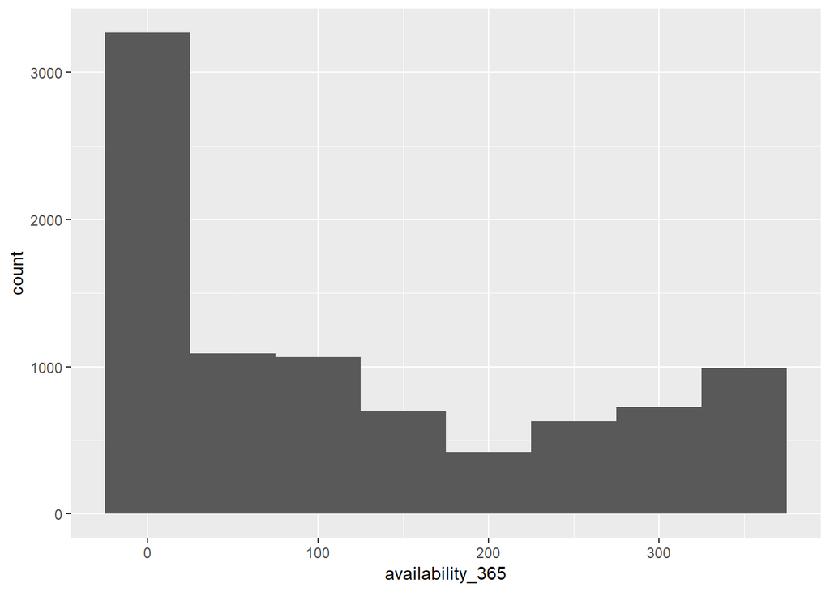

```r
abnb %>%
  ggplot(aes(x = availability_365)) +
  geom_histogram(binwidth = 50)
```

This histogram explores the number of days each listing is available. The possible values are from 0-365. Since we only want listings that are available we will remove all of the listings that have 0 days available and replot.

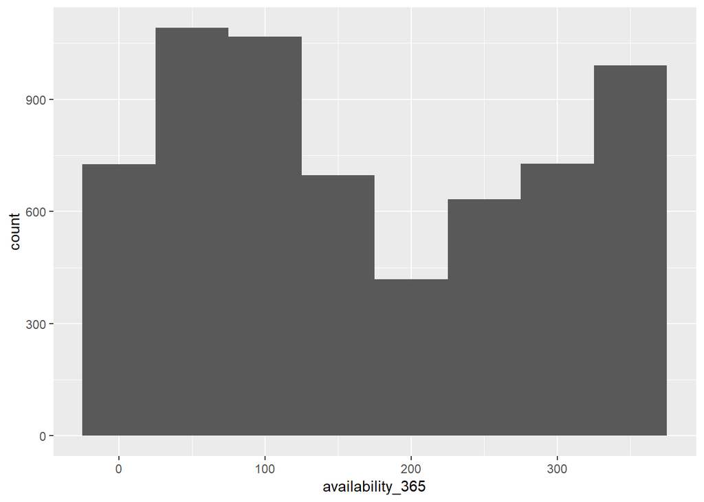

```r
# updates the variable so the availability is at least 1 day
abnb <- abnb[abnb$availability_365 > 0,]

abnb %>%
  ggplot(aes(x = availability_365)) +
  geom_histogram(binwidth = 50)
```

This plot is much more even than before. The data seems to be bimodal with peaks around 50-100 and 300+. The latter makes sense as there are likely many locations that are available 365 days a year.

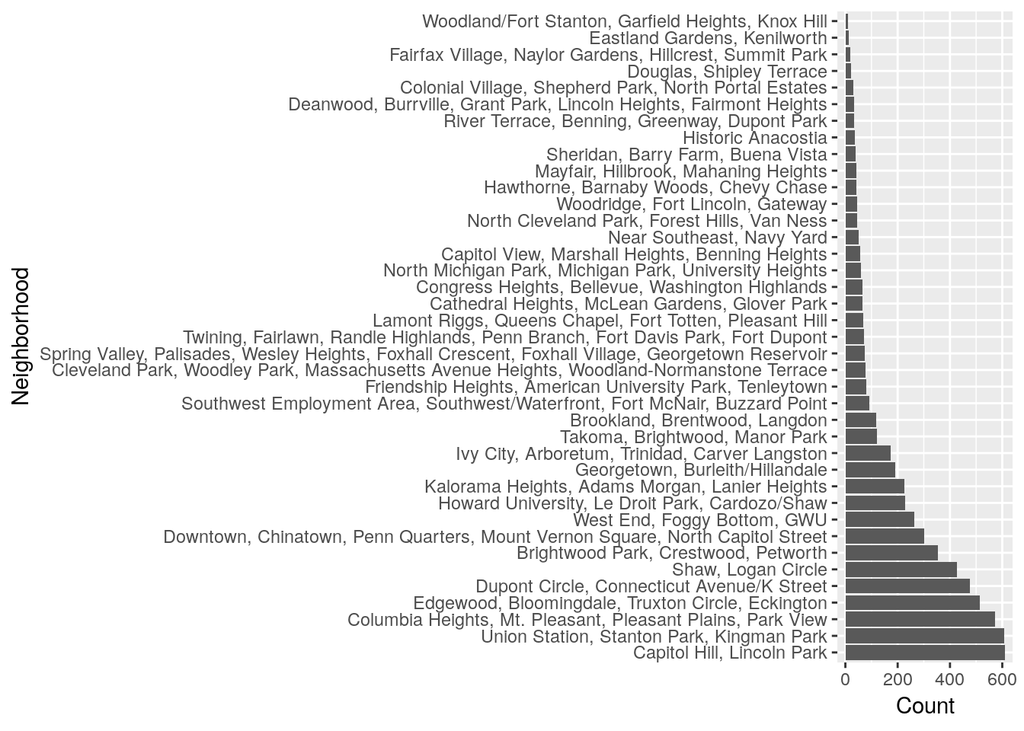

```r
abnb %>%
  group_by(neighbourhood) %>%
  summarize(neigh_count = n()) %>%
  ggplot(aes(x=reorder(neighbourhood, -neigh_count), y=neigh_count)) +
  geom_bar(stat = "identity") +
  labs(x="Neighborhood", y="Count") +
  coord_flip()
```

This plot shows the number of listings that are in each neighborhood in Washington, D.C.. Capitol Hill, Lincoln Park has the most listings with 610.